# assignment5

## Assignment 5

### May 3 2021

### Part 1. 10 pts - Exploratory Data Analysis

```python
import pandas as pd
import numpy as np
import seaborn as sns
import matplotlib.pyplot as plt
from statsmodels.graphics.tsaplots import plot_acf, plot_pacf
from sklearn.model_selection import train_test_split
from sktime.forecasting.all import temporal_train_test_split
from statsmodels.tsa.stattools import kpss, adfuller
import warnings
from pmdarima import auto_arima
from sklearn.metrics import mean_squared_error, mean_absolute_error
import math
from sktime.performance_metrics.forecasting import smape_loss
from sktime.performance_metrics.forecasting import mape_loss
warnings.filterwarnings('ignore')
```

#### A. 5 pts Merge the data sets together, should have 735 rows of data

```python
co2= pd.read_csv("hw5_data_co2.csv")
temp= pd.read_csv("hw5_data_temp.csv")
```

```python
co2['ds'] =co2['ds'].astype('datetime64[ns]').dt.strftime('%Y-%m')
```

```python
temp['ds'] =temp['ds'].astype('datetime64[ns]').dt.strftime('%Y-%m')
```

```python
data = co2.merge(temp, on="ds", how = 'outer')
data.dropna(inplace=True)
data = data.groupby('ds').last()
data
```

| ds | co2 | temp |
| --- | --- | --- |
| 1958-03 | 315.700 | 57.38 |
| 1958-04 | 317.450 | 57.29 |
| 1958-05 | 317.510 | 57.32 |
| 1958-06 | 316.685 | 57.02 |
| 1958-07 | 315.860 | 57.27 |
| ... | ... | ... |
| 2019-01 | 410.920 | 58.29 |
| 2019-02 | 411.660 | 58.37 |
| 2019-03 | 412.000 | 58.59 |
| 2019-04 | 413.510 | 58.50 |
| 2019-05 | 414.830 | 58.50 |

735 rows × 2 columns

#### B. 5 pts Complete a quantitative and qualitative data exploration. Include a verbal summary of your EDA.

```python
data.shape
```

```
(735, 2)
```

```python
missing_values=data['co2'].isna().sum()
full=len(data)
percent=(missing_values/full)*100
percent
```

```
0.0
```

```python
missing_values=data['temp'].isna().sum()
full=len(data)
percent=(missing_values/full)*100
percent
```

```
0.0
```

```python
data.describe()
```

|  | co2 | temp |
| --- | --- | --- |
| count | 735.000000 | 735.000000 |
| mean | 354.210673 | 57.603293 |
| std | 27.922811 | 0.397159 |
| min | 313.200000 | 56.730000 |
| 25% | 328.785000 | 57.280000 |
| 50% | 351.340000 | 57.590000 |
| 75% | 376.515000 | 57.915000 |
| max | 414.830000 | 58.840000 |

```python
data.dtypes
```

```
co2     float64
temp    float64
dtype: object
```

```python
duplicate_rows = data[data.duplicated()]
print("Duplicate rows: ", duplicate_rows.shape)
```

```
Duplicate rows:  (0, 2)
```

```
(array([], dtype=int64),)
```

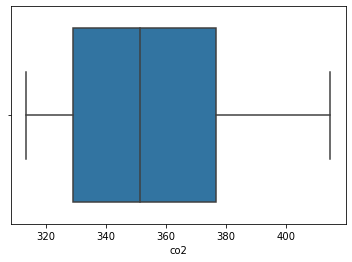

```python
sns.boxplot(x=data['co2'])
print(np.where(data['co2']>data['co2'].quantile(0.75) + (1.5 * (data['co2'].quantile(0.75)-
                                                                  data['co2'].quantile(0.25)))))
```

```
(array([], dtype=int64),)
```

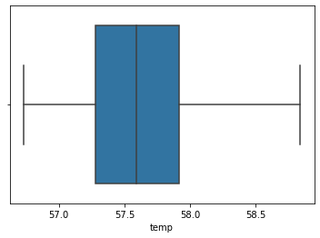

```python
sns.boxplot(x=data['temp'])
print(np.where(data['temp']>data['temp'].quantile(0.75) + (1.5 * (data['temp'].quantile(0.75)-
                                                                  data['temp'].quantile(0.25)))))
```

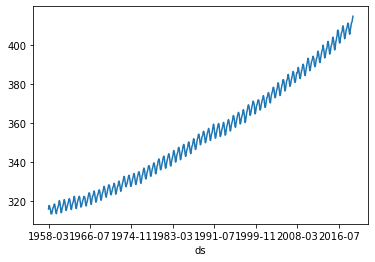

```python
data['co2'].plot()
```

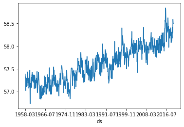

```python
data['temp'].plot()
```

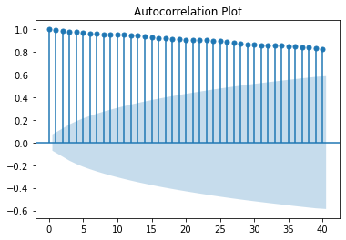

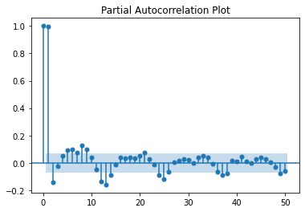

```python
p=plot_acf(data['co2'], lags=40,title='Autocorrelation Plot')
p = plot_pacf(data['co2'],lags=50,  title='Partial Autocorrelation Plot')
```

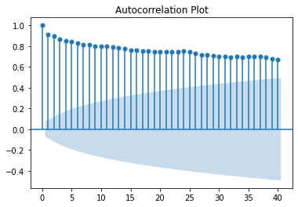

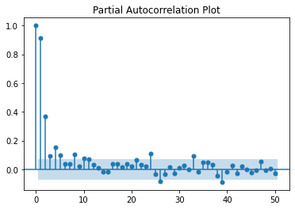

```python
p=plot_acf(data['temp'], lags=40,title='Autocorrelation Plot')
p = plot_pacf(data['temp'],lags=50,  title='Partial Autocorrelation Plot')
```

```python
def adf_kpss_test(timeseries,trend='c'):
    #Perform Dickey-Fuller test:
    df_results=[]
    kpss_results=[]
    print ('Results of Dickey-Fuller Test:')
    dftest = adfuller(timeseries, autolag='AIC')
    dfoutput = pd.Series(dftest[0:4], index=['Test Statistic','p-value','#Lags Used','Number of Observations Used'])
    for key,value in dftest[4].items():
       dfoutput['Critical Value (%s)'%key] = value
    print (dfoutput)
    print("---------------")
    print ('Results of KPSS Test:')
    kpsstest = kpss(timeseries, regression=trend)
    kpss_output = pd.Series(kpsstest[0:3], index=['Test Statistic','p-value','Lags Used'])
    for key,value in kpsstest[3].items():
        kpss_output['Critical Value (%s)'%key] = value
    print (kpss_output)
    for i in dfoutput:
        i=round(i,6)
        df_results.append(i)
    for i in kpss_output:
        i=round(i,6)
        kpss_results.append(i)
    return (df_results,kpss_results)
```

```python
alpha = 0.05
ad_fuller_results,kpss_test_results = adf_kpss_test(data['co2'], trend='c')
ad_fuller_results
ad_fuller_pval = ad_fuller_results[1]
ad_fuller_bool = ad_fuller_pval <= alpha

print(f'stationarity from ad_fuller test: {ad_fuller_bool}')

kpss_pval = kpss_test_results[1]
kpss_test_bool = kpss_pval >= alpha

print(f'stationarity from KPSS test: {kpss_test_bool}')
```

```
Results of Dickey-Fuller Test:
Test Statistic                   5.242612
p-value                          1.000000
#Lags Used                      20.000000
Number of Observations Used    714.000000
Critical Value (1%)             -3.439542
Critical Value (5%)             -2.865596
Critical Value (10%)            -2.568930
dtype: float64
---------------
Results of KPSS Test:
Test Statistic            3.55359
p-value                   0.01000
Lags Used                20.00000
Critical Value (10%)      0.34700
Critical Value (5%)       0.46300
Critical Value (2.5%)     0.57400
Critical Value (1%)       0.73900
dtype: float64
stationarity from ad_fuller test: False
stationarity from KPSS test: False
```

```python
alpha = 0.05
ad_fuller_results,kpss_test_results = adf_kpss_test(data['temp'], trend='c')
ad_fuller_results
ad_fuller_pval = ad_fuller_results[1]
ad_fuller_bool = ad_fuller_pval <= alpha

print(f'stationarity from ad_fuller test: {ad_fuller_bool}')

kpss_pval = kpss_test_results[1]
kpss_test_bool = kpss_pval >= alpha

print(f'stationarity from KPSS test: {kpss_test_bool}')
```

```
Results of Dickey-Fuller Test:
Test Statistic                  -1.120522
p-value                          0.706819
#Lags Used                      10.000000
Number of Observations Used    724.000000
Critical Value (1%)             -3.439414
Critical Value (5%)             -2.865540
Critical Value (10%)            -2.568900
dtype: float64
---------------
Results of KPSS Test:
Test Statistic            3.347826
p-value                   0.010000
Lags Used                20.000000
Critical Value (10%)      0.347000
Critical Value (5%)       0.463000
Critical Value (2.5%)     0.574000
Critical Value (1%)       0.739000
dtype: float64
stationarity from ad_fuller test: False
stationarity from KPSS test: False
```

### Part 2. 35 pts – ARIMA with external regressors

#### A. 7 pts Split into train test. Determine the transformation, seasonal differencing & non seasonal differencing orders if required. Include the following: plot of differenced data, ADF results, kpss results, ACF/PACF plots.

```python
import pandas as pd
import matplotlib.pyplot as plt
import statsmodels.api as sm
from statsmodels.tsa.stattools import kpss, adfuller
from statsmodels.tsa.statespace import sarimax
from statsmodels.tools.eval_measures import aicc
from statsmodels.graphics.tsaplots import plot_acf, plot_pacf
from sktime.datasets import load_airline
from sktime.transformations.series import boxcox
# from scipy import stats
from sktime.forecasting.arima import ARIMA
```

Converting to proper format and setting frequency

```python
data_series=data['temp']
data_series.index=pd.core.indexes.period.PeriodIndex(data.index.tolist(),freq='m')
data_series
```

```
1958-03    57.38
1958-04    57.29
1958-05    57.32
1958-06    57.02
1958-07    57.27
           ...
2019-01    58.29
2019-02    58.37
2019-03    58.59
2019-04    58.50
2019-05    58.50
Freq: M, Name: temp, Length: 735, dtype: float64
```

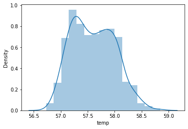

```python
sns.distplot(data_series)
plt.show()
```

Here, I saw that the temperature dataseries almost has a normal distribution. Therefore, I felt that we did not need to do a box cox transformation. I went stright to splitting the data and using differencing.

```python
y_train, y_test = temporal_train_test_split(data_series)
```

```python
y_train_nonseas_diff = y_train.diff().dropna()
y_train_nonseas_diff
```

```
1958-04   -0.09
1958-05    0.03
1958-06   -0.30
1958-07    0.25
1958-08   -0.17
           ...
2003-09   -0.03
2003-10    0.03
2003-11   -0.21
2003-12    0.22
2004-01   -0.14
Freq: M, Name: temp, Length: 550, dtype: float64
```

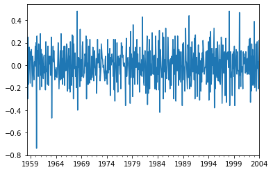

```python
y_train_nonseas_diff.plot()
```

```python
alpha = 0.05
ad_fuller_results,kpss_test_results = adf_kpss_test(y_train_nonseas_diff, trend='c')
ad_fuller_results
ad_fuller_pval = ad_fuller_results[1]
ad_fuller_bool = ad_fuller_pval <= alpha

print(f'stationarity from ad_fuller test: {ad_fuller_bool}')

kpss_pval = kpss_test_results[1]
kpss_test_bool = kpss_pval >= alpha

print(f'stationarity from KPSS test: {kpss_test_bool}')
```

```
Results of Dickey-Fuller Test:
Test Statistic                -1.215938e+01
p-value                        1.505895e-22
#Lags Used                     6.000000e+00
Number of Observations Used    5.430000e+02
Critical Value (1%)           -3.442450e+00
Critical Value (5%)           -2.866877e+00
Critical Value (10%)          -2.569613e+00
dtype: float64
---------------
Results of KPSS Test:
Test Statistic            0.049108
p-value                   0.100000
Lags Used                19.000000
Critical Value (10%)      0.347000
Critical Value (5%)       0.463000
Critical Value (2.5%)     0.574000
Critical Value (1%)       0.739000
dtype: float64
stationarity from ad_fuller test: True
stationarity from KPSS test: True
```

The plot of the differenced data looks to be stationary. I do not see a varying mean or variance. I moved forward and performed the adf and kpss tests and found that indeed the data was stationary once being differenced.

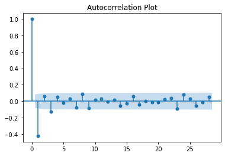

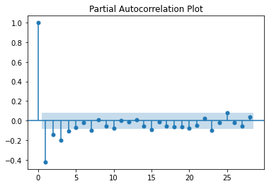

```python
p = plot_acf(y_train_nonseas_diff, title='Autocorrelation Plot')
p = plot_pacf(y_train_nonseas_diff, title='Partial Autocorrelation Plot')
```

Above are the acf and pacf plots. I decided to keep the lag at 0 because it helps me confirm that at lag 0, the data correlates with itself and therefore shows 1.

#### B. 7 pts Fit a SARIMA or ARIMA model based on your examinations. Examine the residuals. Include the following: plot, histogram, ACF, Ljung Box results. Check if auto arima gives you a different order. If this is a better model, examine the residuals of this model.

I chose to use 3,1,1 as the order. After analyzing the acf and pacf plots from above, I saw that in the acf plot, it decays after lag 1. So for the MA component, I used 1. When I examined the pacf plot, I saw that the significant lags wer 1,2,and 3 and then it tapers off. I kept the spike at lag 0. The autocorrelation at lag 0 that is the large spike. It is 1.0, so we know that a time series is 100% correlated with itself. If we take 2 copies of the same time series, which is same as lag=0, we should see 100% correlation. I used this method from the ta session.

```python
arima_model = sm.tsa.statespace.SARIMAX(endog=y_train,order=(3,1,1))
arima_fit = arima_model.fit()
print(arima_fit.summary())
```

```
                               SARIMAX Results
==============================================================================
Dep. Variable:                   temp   No. Observations:                  551
Model:               SARIMAX(3, 1, 1)   Log Likelihood                 302.100
Date:                Wed, 05 May 2021   AIC                           -594.200
Time:                        08:41:01   BIC                           -572.650
Sample:                    03-31-1958   HQIC                          -585.779
                         - 01-31-2004
Covariance Type:                  opg
==============================================================================
                 coef    std err          z      P>|z|      [0.025      0.975]
------------------------------------------------------------------------------
ar.L1          0.3787      0.047      7.997      0.000       0.286       0.472
ar.L2          0.2274      0.051      4.446      0.000       0.127       0.328
ar.L3          0.0143      0.051      0.279      0.780      -0.086       0.115
ma.L1         -0.9456      0.022    -42.995      0.000      -0.989      -0.902
sigma2         0.0195      0.001     19.038      0.000       0.017       0.021
===================================================================================
Ljung-Box (L1) (Q):                   0.02   Jarque-Bera (JB):                11.09
Prob(Q):                              0.90   Prob(JB):                         0.00
Heteroskedasticity (H):               1.19   Skew:                             0.02
Prob(H) (two-sided):                  0.24   Kurtosis:                         3.69
===================================================================================

Warnings:
[1] Covariance matrix calculated using the outer product of gradients (complex-step).
```

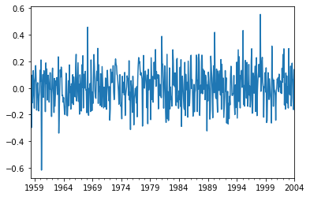

```python
resid = arima_fit.resid
resid=resid[1:]
resid.plot()
plt.show()
```

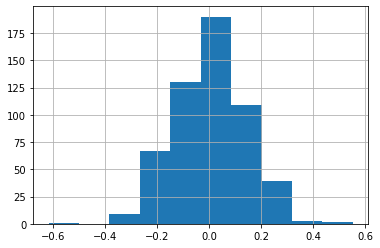

```python
resid.hist()
```

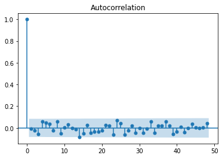

```python
plot_acf(resid, lags=48)
plt.show()
```

```python
sm.stats.acorr_ljungbox(resid, lags=[10], return_df=True, boxpierce=True)
```

|  | lb_stat | lb_pvalue | bp_stat | bp_pvalue |
| --- | --- | --- | --- | --- |
| 10 | 10.089745 | 0.432655 | 9.949535 | 0.444932 |

Now, I will fit an auto arima and see if it gives a better result.

```python
from pmdarima import auto_arima
am=auto_arima(y_train, seasonal=False,start_p=0,d=1,start_q=0,
          suppress_warnings=True)
am.fit(y_train)
```

```
ARIMA(order=(2, 1, 1), scoring_args={}, suppress_warnings=True)
```

```python
am.summary()
```

SARIMAX Results

| Dep. Variable: | y | No. Observations: | 551 |
| --- | --- | --- | --- |
| Model: | SARIMAX(2, 1, 1) | Log Likelihood | 303.707 |
| Date: | Wed, 05 May 2021 | AIC | -597.414 |
| Time: | 08:41:08 | BIC | -575.865 |
| Sample: | 0 | HQIC | -588.993 |
|  | - 551 |  |  |
| Covariance Type: | opg |  |  |

|  | coef | std err | z | P>\|z\| | [0.025 | 0.975] |
| --- | --- | --- | --- | --- | --- | --- |
| intercept | 0.0005 | 0.000 | 2.352 | 0.019 | 7.91e-05 | 0.001 |
| ar.L1 | 0.4027 | 0.045 | 9.049 | 0.000 | 0.315 | 0.490 |
| ar.L2 | 0.2498 | 0.048 | 5.256 | 0.000 | 0.157 | 0.343 |
| ma.L1 | -0.9704 | 0.013 | -72.591 | 0.000 | -0.997 | -0.944 |
| sigma2 | 0.0194 | 0.001 | 18.969 | 0.000 | 0.017 | 0.021 |

| Ljung-Box (L1) (Q): | 0.03 | Jarque-Bera (JB): | 11.20 |
| --- | --- | --- | --- |
| Prob(Q): | 0.87 | Prob(JB): | 0.00 |
| Heteroskedasticity (H): | 1.18 | Skew: | 0.03 |
| Prob(H) (two-sided): | 0.27 | Kurtosis: | 3.70 |

Warnings:  
[1] Covariance matrix calculated using the outer product of gradients (complex-step).

```python
residuals=pd.Series(am.resid())
residuals=residuals[1:]
```

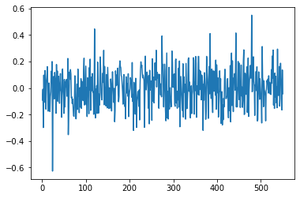

```python
residuals.plot()
```

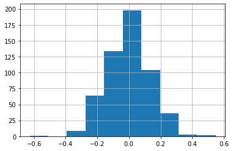

```python
residuals.hist()
```

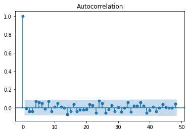

```python
plot_acf(residuals, lags=48)
plt.show()
```

```python
sm.stats.acorr_ljungbox(residuals, lags=[15], return_df=True, boxpierce=True)
```

|  | lb_stat | lb_pvalue | bp_stat | bp_pvalue |
| --- | --- | --- | --- | --- |
| 15 | 16.439935 | 0.353431 | 16.141745 | 0.372694 |

To validate our models, we can look the model residuals. The residuals are the difference between the actual data and the predicted value from the (s)arima model. Based on the visuals above, they are performing as residuals should.

Plot (Model 1)

The plot of the residuals look like white noise. This way, I can be sure that none of the signal has escaped my model fit and has ended up in the residuals by mistake.

Plot (Model 2)

Here also, the plot of the residuals look like white noise. This way, I can be sure that none of the signal has escaped my model fit and has ended up in the residuals by mistake.

Histogram (Model 1)

The residuals should also be normally distributed. My histagram shows a normally distributed model. You can see the mean is centered around 0. A normally distributed residuals describes the actual distribution of the random errors in actuality reasonably well.

Histogram (Model 2)

Here also, the residuals should also be normally distributed. The two histogram above are very similar with only a slight difference. My histagram shows a normally distributed model. You can see the mean is centered around 0. A normally distributed residuals describes the actual distribution of the random errors in actuality reasonably well.

ACF (Model 1) The residuals should not show a trend or autocorrelation, because then we have failed to capture it in our model instead. The residuals should be stationary. In the ACF plot, I can see there isn't much autocorrelation. For ACF the AC at lag 0 that is the only large spike. It is 1.0, so we know that a time series is 100% correlated with itself. If we take 2 copies of the same time series, which is same as lag=0, we see 100% correlation.

Ljung Box (Model 1)

I also performed the Ljung box test (portmanteau). The p-value of the test is 0.43, which is well above 0.05. A significant p-value in this test rejects the null hypothesis that the time series isn't autocorrelated. But since the pvalue is insignificant, we can accept the null hypothesis and confirm that the model does show a lack of fit and there is no autocorrelation and thus is a good model.

Ljung Box (Model 2)

Here, the p-value of the test is 0.35, which is also well above 0.05. A significant p-value in this test rejects the null hypothesis that the time series isn't autocorrelated. But since the pvalue is insignificant, we can accept the null hypothesis and confirm that the model does show a lack of fit and there is no autocorrelation and thus is a good model.

#### C. 7 pts Using your best model, predict the test set. Include the following: MAE, MSE, MAPE, sMAPE, MASE. Can use prebuilt functions or calculate by hand.

My best model from above was the autoarima one with the order of 2,1,1. This one had a lower aic score: -597 as compared to my arima model which had an aic score of -594. Also, examining the residuals, I saw that the two models were very similar.

```python
y_pred = pd.DataFrame(am.predict(n_periods = len(y_test)),index=y_test.index)
y_pred.columns = ['temp']
```

```python
y_pred_series=y_pred['temp']
y_pred_series.index=pd.core.indexes.period.PeriodIndex(y_test.index.tolist(),freq='m')
y_pred_series
```

```
2004-02    57.962523
2004-03    57.945145
2004-04    57.949245
2004-05    57.947029
2004-06    57.947635
             ...
2019-01    58.182530
2019-02    58.183895
2019-03    58.185260
2019-04    58.186626
2019-05    58.187991
Freq: M, Name: temp, Length: 184, dtype: float64
```

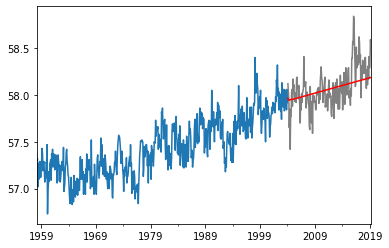

```python
y_train.plot()
y_test.plot(color = 'grey')
y_pred_series.plot(color='red')
```

```python
def MASE(training_series, testing_series, prediction_series):

    n = training_series.shape[0]
    d = np.abs(  np.diff( training_series) ).sum()/(n-1)

    errors = np.abs(testing_series - prediction_series )
    return errors.mean()/d
```

```python
mae = mean_absolute_error(y_test, y_pred_series)
mse = mean_squared_error(y_test, y_pred_series)
rmse = math.sqrt(mse)
smape = smape_loss(y_test, y_pred_series)
mape = mape_loss(y_test, y_pred_series)
mase= MASE(y_train, y_test, y_pred_series)
```

```python
print(f'Mean Squared Error: {mse}')
print(f'Root Mean Squared Error: {rmse}')
print(f'Mean Absolute Error: {mae}')
print(f'SMAPE: {smape}')
print(f'MAPE: {mape}')
print(f'MASE: {mase}')
```

```
Mean Squared Error: 0.03585643822587163
Root Mean Squared Error: 0.18935796319635367
Mean Absolute Error: 0.1448231955486942
SMAPE: 0.0024923301951223814
MAPE: 0.002491040306921248
MASE: 1.1346546659797976
```

#### D. 7 pts Refit your best model by adding co2 as an external regressor. Examine the residuals of this model.

```python
import numpy as np
import pandas as pd
from scipy.stats import norm
import statsmodels.api as sm
import matplotlib.pyplot as plt
from datetime import datetime
import requests
from io import BytesIO
```

```python
y_train, y_test = temporal_train_test_split(data)
```

```python
endog = y_train['temp']
exog = y_train['co2']
```

```python
endog.index.name='ds'
endog.index=pd.core.indexes.period.PeriodIndex(y_train.index.tolist(),freq='m')
endog.index
```

```
PeriodIndex(['1958-03', '1958-04', '1958-05', '1958-06', '1958-07', '1958-08',
             '1958-09', '1958-10', '1958-11', '1958-12',
             ...
             '2003-04', '2003-05', '2003-06', '2003-07', '2003-08', '2003-09',
             '2003-10', '2003-11', '2003-12', '2004-01'],
            dtype='period[M]', length=551, freq='M')
```

```python
exog.index=pd.core.indexes.period.PeriodIndex(y_train.index.tolist(),freq='m')

exog.index
```

```
PeriodIndex(['1958-03', '1958-04', '1958-05', '1958-06', '1958-07', '1958-08',
             '1958-09', '1958-10', '1958-11', '1958-12',
             ...
             '2003-04', '2003-05', '2003-06', '2003-07', '2003-08', '2003-09',
             '2003-10', '2003-11', '2003-12', '2004-01'],
            dtype='period[M]', length=551, freq='M')
```

```python
mod = sm.tsa.statespace.SARIMAX(endog, exog, order=(2,1,1))
exreg = mod.fit(disp=False)
print(exreg.summary())
```

```
                               SARIMAX Results
==============================================================================
Dep. Variable:                   temp   No. Observations:                  551
Model:               SARIMAX(2, 1, 1)   Log Likelihood                 306.808
Date:                Wed, 05 May 2021   AIC                           -603.615
Time:                        08:41:12   BIC                           -582.066
Sample:                    03-31-1958   HQIC                          -595.194
                         - 01-31-2004
Covariance Type:                  opg
==============================================================================
                 coef    std err          z      P>|z|      [0.025      0.975]
------------------------------------------------------------------------------
co2            0.0133      0.001     13.391      0.000       0.011       0.015
ar.L1          0.4105      0.042      9.722      0.000       0.328       0.493
ar.L2          0.2610      0.045      5.755      0.000       0.172       0.350
ma.L1         -0.9994      0.074    -13.422      0.000      -1.145      -0.853
sigma2         0.0190      0.002     11.243      0.000       0.016       0.022
===================================================================================
Ljung-Box (L1) (Q):                   0.08   Jarque-Bera (JB):                 8.11
Prob(Q):                              0.78   Prob(JB):                         0.02
Heteroskedasticity (H):               1.13   Skew:                             0.00
Prob(H) (two-sided):                  0.40   Kurtosis:                         3.59
===================================================================================

Warnings:
[1] Covariance matrix calculated using the outer product of gradients (complex-step).
```

```python
residuals=exreg.resid
residuals=residuals[1:]
residuals
```

```
1958-04   -0.113250
1958-05   -0.018956
1958-06   -0.288243
1958-07    0.113533
1958-08   -0.086437
             ...
2003-09    0.105907
2003-10    0.077390
2003-11   -0.160267
2003-12    0.128032
2004-01   -0.050336
Freq: M, Length: 550, dtype: float64
```

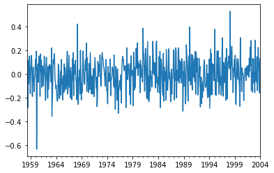

```python
residuals.plot()
plt.show()
```

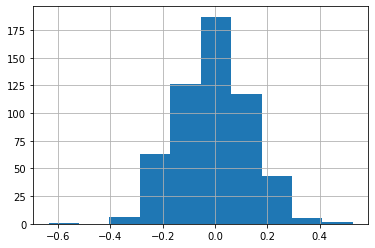

```python
residuals.hist()
```

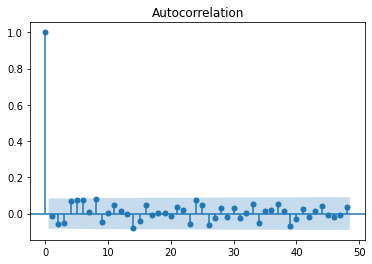

```python
plot_acf(residuals, lags=48)
plt.show()
```

```python
sm.stats.acorr_ljungbox(residuals, lags=[10], return_df=True, boxpierce=True)
```

|  | lb_stat | lb_pvalue | bp_stat | bp_pvalue |
| --- | --- | --- | --- | --- |
| 10 | 16.846037 | 0.077841 | 16.621165 | 0.083178 |

To validate our models, we can look the model residuals. The residuals are the difference between the actual data and the predicted value from the auto arima model. Based on the visuals above, they are performing as residuals should.

Plot

The plot of the residuals look like white noise. This way, I can be sure that none of the signal has escaped my model fit and has ended up in the residuals by mistake. It also looks pretty stationary.

Histogram

The residuals should also be normally distributed. My histagram shows a normally distributed model. You can see the mean is centered around 0. A normally distributed residuals describes the actual distribution of the random errors in actuality reasonably well. I also like this histogram because it has a pretty symmetrical bell curve shape.

ACF

The residuals should not show a trend or autocorrelation, because then we have failed to capture it in our model instead. The residuals should be stationary. In the ACF plot, I can see there isn't much autocorrelation. For ACF the AC at lag 0 that is the only large spike. It is 1.0, so we know that a time series is 100% correlated with itself. If we take 2 copies of the same time series, which is same as lag=0, we see 100% correlation.

Ljung Box

I also performed the Ljung box test (portmanteau). The p-value of the test is 0.077, which is above 0.05. A significant p-value in this test rejects the null hypothesis that the time series isn't autocorrelated. But since the pvalue is insignificant, we can accept the null hypothesis and confirm that the model does show a lack of fit and there is no autocorrelation and thus is a good model.

#### E. 7 pts Predict the test set. Include the following: MAE, MSE, MAPE, sMAPE, MASE. Can use prebuilt functions or calculate by hand.

```python
predictions = exreg.predict(start = '2004-02', end = '2019-05',exog=y_test['co2'], dynamic= True)
predictions
```

```
2004-02    57.967248
2004-03    57.956682
2004-04    57.985135
2004-05    57.980608
2004-06    57.963988
             ...
2019-01    58.370998
2019-02    58.380829
2019-03    58.385347
2019-04    58.405408
2019-05    58.422946
Freq: M, Name: predicted_mean, Length: 184, dtype: float64
```

```python
y_train_temp=y_train['temp']
y_train_temp.index=pd.core.indexes.period.PeriodIndex(y_train['temp'].index.tolist(),freq='m')
```

```python
y_test_temp=y_test['temp']
y_test_temp.index=pd.core.indexes.period.PeriodIndex(y_test['temp'].index.tolist(),freq='m')
```

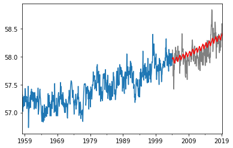

```python
y_train_temp.plot()
y_test_temp.plot(color = 'grey')
predictions.plot(color='red')
```

```python
def MASE(training_series, testing_series, prediction_series):

    n = training_series.shape[0]
    d = np.abs(  np.diff( training_series) ).sum()/(n-1)

    errors = np.abs(testing_series - prediction_series )
    return errors.mean()/d
```

```python
mae = mean_absolute_error(y_test_temp, predictions)
mse = mean_squared_error(y_test_temp, predictions)
rmse = math.sqrt(mse)
smape = smape_loss(y_test_temp, predictions)
mape = mape_loss(y_test_temp, predictions)
mase= MASE(y_train_temp, y_test_temp, predictions)
```

```python
print(f'Mean Squared Error: {mse}')
print(f'Root Mean Squared Error: {rmse}')
print(f'Mean Absolute Error: {mae}')
print(f'SMAPE: {smape}')
print(f'MAPE: {mape}')
print(f'MASE: {mase}')
```

```
Mean Squared Error: 0.03522246690530079
Root Mean Squared Error: 0.18767649534584982
Mean Absolute Error: 0.1453903511764194
SMAPE: 0.00250264837914994
MAPE: 0.0025048279491150737
MASE: 1.1390981929776447
```

### Part 3. 35 pts – Prophet with additional regressors

#### A. 10 pts Using the same train test split as part 2, fit a prophet model to your NON-differenced training set. Examine the residuals. Using the predicted values and y train, calculate the following: MAE, MSE, MAPE, sMAPE, MASE. Can use prebuilt functions or calculate by hand.

```python
import pystan
import copy
import matplotlib.pyplot as plt

import pandas as pd
from util_prophet import *
from fbprophet import Prophet
```

```python
data_temp=data['temp']
data_temp
```

```
1958-03    57.38
1958-04    57.29
1958-05    57.32
1958-06    57.02
1958-07    57.27
           ...
2019-01    58.29
2019-02    58.37
2019-03    58.59
2019-04    58.50
2019-05    58.50
Freq: M, Name: temp, Length: 735, dtype: float64
```

```python
y_train, y_test = temporal_train_test_split(data_temp)
```

```python
y_train = y_train.reset_index()
y_test = y_test.reset_index()
y_train = y_train.rename(columns={'temp': 'y','index':'ds'})
y_test = y_test.rename(columns={'temp': 'y','index':'ds'})
```

```python
y_train['ds'] = y_train['ds'].dt.to_timestamp('s')
y_test['ds'] = y_test['ds'].dt.to_timestamp('s')
```

```python
model = Prophet()
model.fit(y_train)
```

```
INFO:fbprophet:Disabling weekly seasonality. Run prophet with weekly_seasonality=True to override this.
INFO:fbprophet:Disabling daily seasonality. Run prophet with daily_seasonality=True to override this.
```

```
<fbprophet.forecaster.Prophet at 0x1d75c5d6988>
```

```python
future_data = model.make_future_dataframe(periods=len(y_test), freq='m')
```

```python
forecast_data = model.predict(future_data)
forecast_data.iloc[0:3]
```

|  | ds | trend | yhat_lower | yhat_upper | trend_lower | trend_upper | additive_terms | additive_terms_lower | additive_terms_upper | yearly | yearly_lower | yearly_upper | multiplicative_terms | multiplicative_terms_lower | multiplicative_terms_upper | yhat |
| --- | --- | --- | --- | --- | --- | --- | --- | --- | --- | --- | --- | --- | --- | --- | --- | --- |
| 0 | 1958-03-01 | 57.214752 | 57.097737 | 57.474041 | 57.214752 | 57.214752 | 0.062588 | 0.062588 | 0.062588 | 0.062588 | 0.062588 | 0.062588 | 0.0 | 0.0 | 0.0 | 57.277340 |
| 1 | 1958-04-01 | 57.215070 | 57.054177 | 57.443814 | 57.215070 | 57.215070 | 0.031795 | 0.031795 | 0.031795 | 0.031795 | 0.031795 | 0.031795 | 0.0 | 0.0 | 0.0 | 57.246865 |
| 2 | 1958-05-01 | 57.215378 | 57.066327 | 57.417777 | 57.215378 | 57.215378 | 0.020436 | 0.020436 | 0.020436 | 0.020436 | 0.020436 | 0.020436 | 0.0 | 0.0 | 0.0 | 57.235814 |

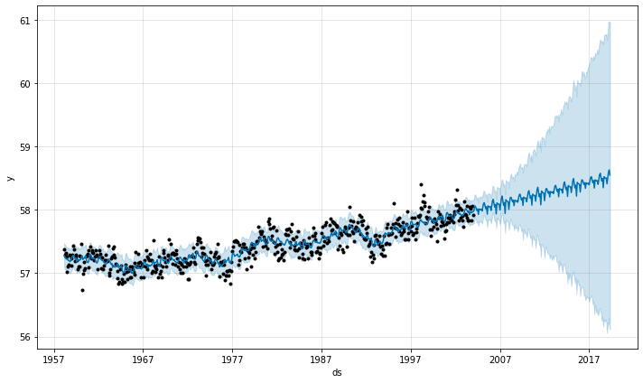

```python
p = model.plot(forecast_data)
```

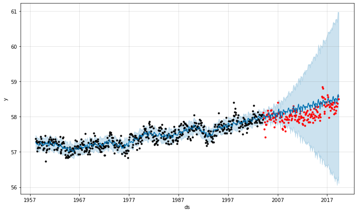

```python
p = model.plot(forecast_data)
plt.scatter(pd.to_datetime(y_test['ds']),pd.to_numeric(y_test['y']), color='r', marker='.')
plt.show()
```

```python
residuals =  y_train['y']-forecast_data['yhat'][:551]
residuals=residuals[1:]
residuals
```

```
1      0.043135
2      0.084186
3     -0.202996
4      0.035071
5     -0.104888
         ...
546    0.051125
547    0.092305
548   -0.113487
549    0.089081
550   -0.054024
Length: 550, dtype: float64
```

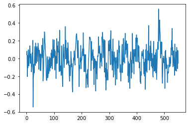

```python
residuals.plot()
```

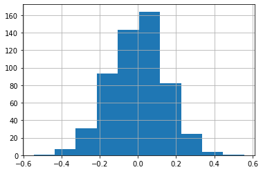

```python
residuals.hist()
```

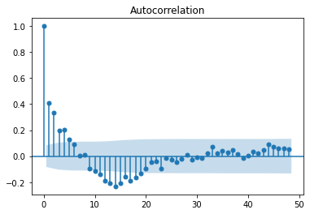

```python
plot_acf(residuals, lags=48)
plt.show()
```

```python
sm.stats.acorr_ljungbox(residuals, lags=[15], return_df=True, boxpierce=True)
```

|  | lb_stat | lb_pvalue | bp_stat | bp_pvalue |
| --- | --- | --- | --- | --- |
| 15 | 337.115581 | 1.035116e-62 | 332.193606 | 1.102854e-61 |

Plot

Histogram

The residuals should also be normally distributed. My histagram shows a normally distributed model. You can see the mean is centered around 0. A normally distributed residuals describes the actual distribution of the random errors in actuality reasonably well. I also like this histogram because it has a pretty symmetrical bell curve shape.

ACF

Ljung Box

I also performed the Ljung box test (portmanteau). The p-value of the test is close to 0, which is less than 0.05. A significant p-value in this test rejects the null hypothesis that the time series isn't autocorrelated. Since the pvalue is significant, we can reject the null hypothesis and confirm that the model does not show a lack of fit and there is autocorrelation and thus is not a good model.

Now, I do the error metrics on the TRAINING set

```python
y_pred=forecast_data['yhat'][:551]
y_pred
```

```
0      57.277340
1      57.246865
2      57.235814
3      57.222996
4      57.234929
         ...
546    57.968875
547    57.957695
548    57.953487
549    57.970919
550    57.974024
Name: yhat, Length: 551, dtype: float64
```

```python
def MASE(training_series, testing_series, prediction_series):

    n = training_series.shape[0]
    d = np.abs(  np.diff( training_series) ).sum()/(n-1)

    errors = np.abs(testing_series - prediction_series )
    return errors.mean()/d
```

```python
mae = mean_absolute_error(y_train['y'], y_pred)
mse = mean_squared_error(y_train['y'], y_pred)
rmse = math.sqrt(mse)
smape = smape_loss(y_train['y'], y_pred)
mape = mape_loss(y_train['y'], y_pred)
mase= mae/MASE(y_train['y'], y_train['y'], y_pred)
```

```python
print(f'Mean Squared Error: {mse}')
print(f'Root Mean Squared Error: {rmse}')
print(f'Mean Absolute Error: {mae}')
print(f'SMAPE: {smape}')
print(f'MAPE: {mape}')
print(f'MASE: {mase}')
```

```
Mean Squared Error: 0.021341208722142974
Root Mean Squared Error: 0.14608630573104028
Mean Absolute Error: 0.11590502697284465
SMAPE: 0.002017541374113502
MAPE: 0.0020176013387167148
MASE: 0.12763636363636366
```

#### B. 10 pts Adjust seasonality, changepoint priors or other methods to see if you can create a better fit model. Examine the residuals. Using the predicted values and y train, calculate the following: MAE, MSE, MAPE, sMAPE, MASE. Can use prebuilt functions or calculate by hand.

```python
from fbprophet.diagnostics import cross_validation
import itertools
import numpy as np
import pandas as pd
```

```python
y_train['ds']= pd.to_datetime(y_train['ds'])
```

```python
cutoffs = pd.to_datetime([ '1975-02-01', '1985-02-01','1995-02-01'])

param_grid = {
    'changepoint_prior_scale': [0.001, 0.01, 0.1,0.5 ],
    'seasonality_prior_scale': [0.01, 0.1, 1.0,10.0],
}

# Generate all combinations of parameters
all_params = [dict(zip(param_grid.keys(), v)) for v in itertools.product(*param_grid.values())]
rmses = []  # Store the RMSEs for each params here

# Use cross validation to evaluate all parameters
for params in all_params:
    m = Prophet(**params).fit(y_train)  # Fit model with given params
    df_cv = cross_validation(m, cutoffs=cutoffs, horizon='30 days', parallel="processes")
    df_p = performance_metrics(df_cv, rolling_window=1)
    rmses.append(df_p['rmse'].values[0])

# Find the best parameters
tuning_results = pd.DataFrame(all_params)
tuning_results['rmse'] = rmses
print(tuning_results)
```

[output not shown]

```
    changepoint_prior_scale  seasonality_prior_scale      rmse
0                     0.001                     0.01  0.064769
1                     0.001                     0.10  0.065795
2                     0.001                     1.00  0.057273
3                     0.001                    10.00  0.059061
4                     0.010                     0.01  0.053422
5                     0.010                     0.10  0.048836
6                     0.010                     1.00  0.049602
7                     0.010                    10.00  0.050262
8                     0.100                     0.01  0.077342
9                     0.100                     0.10  0.077104
10                    0.100                     1.00  0.077320
11                    0.100                    10.00  0.077294
12                    0.500                     0.01  0.083585
13                    0.500                     0.10  0.083362
14                    0.500                     1.00  0.083283
15                    0.500                    10.00  0.083024
```

I used hyper parameter tuning and tried different combinations of change point prior and seasonality priors and found the combination that had the lowest rmse. In this, I found that the lowest rmse of 0.048836 resulted from a model where the changepoint prior was 0.01 and the seasonality prior was 0.1

```python
modeltuned = Prophet(changepoint_prior_scale=0.01, seasonality_prior_scale=0.1,yearly_seasonality=False)
# modeltuned.add_seasonality(
#         name='yearly', period =1, fourier_order=5)
modeltuned.fit(y_train)
future_data = modeltuned.make_future_dataframe(periods=len(y_test), freq='m')
forecast_data = modeltuned.predict(future_data)
forecast_data[:3]
```

```
INFO:fbprophet:Disabling weekly seasonality. Run prophet with weekly_seasonality=True to override this.
INFO:fbprophet:Disabling daily seasonality. Run prophet with daily_seasonality=True to override this.
```

|  | ds | trend | yhat_lower | yhat_upper | trend_lower | trend_upper | additive_terms | additive_terms_lower | additive_terms_upper | multiplicative_terms | multiplicative_terms_lower | multiplicative_terms_upper | yhat |
| --- | --- | --- | --- | --- | --- | --- | --- | --- | --- | --- | --- | --- | --- |
| 0 | 1958-03-01 | 57.258055 | 57.061196 | 57.473458 | 57.258055 | 57.258055 | 0.0 | 0.0 | 0.0 | 0.0 | 0.0 | 0.0 | 57.258055 |
| 1 | 1958-04-01 | 57.256304 | 57.056997 | 57.461746 | 57.256304 | 57.256304 | 0.0 | 0.0 | 0.0 | 0.0 | 0.0 | 0.0 | 57.256304 |
| 2 | 1958-05-01 | 57.254610 | 57.040833 | 57.442766 | 57.254610 | 57.254610 | 0.0 | 0.0 | 0.0 | 0.0 | 0.0 | 0.0 | 57.254610 |